# STATS762 Assignment 1 ID:2343672 Danmei Li

```r
library(quantreg)
library(pscl)
game.train=read.csv(file='Craft_train.csv',header=TRUE)
game.test=read.csv(file='Craft_test.csv',header=TRUE)

# nrow(game.test)
# [1] 557
```

### Question 1

### 1. Actions per minute (APM) is often used as a predictor of expertise in the

### StarCraft community. We want to model the quantile of APM given a

### player’s league index using a linear regression model.

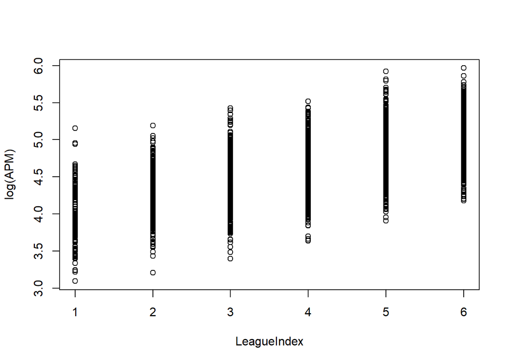

```r
plot(log(APM)~LeagueIndex,game.train)
```

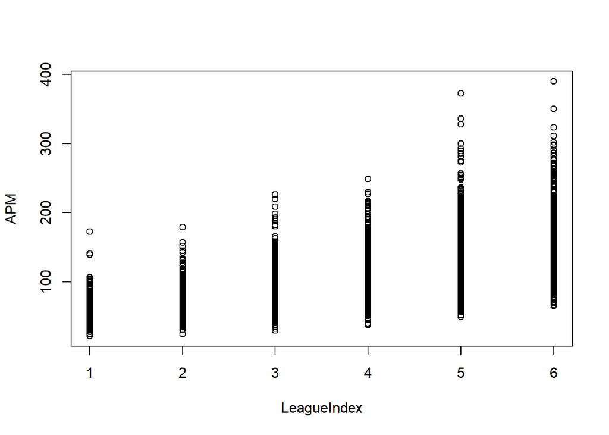

```r
plot(APM~LeagueIndex,game.train)
```

### (a) [4 marks]

### We want to model the 0.5 quantile of APM against league index. One

### says an actual APM value is better than a logged APM value. Fit 0.5

### quantile regressions for actual APM values and logged APM values.

### For each model, present a scatter plot of test data (Craft test.csv)

### and prediction in a single plot. [4 marks]

### Action AMP is often used as a predictor of expertise in the StarCraft community

### Want to model quantile of APM given a player’s leagueIndex using

### linear regression

```r
# str(game.train)
#
# 'data.frame': 3300 obs. of  20 variables:
#  $ GameID              : int  631 3311 7695 6745 649 8434 5634 7863 6857 6056 ...
#  $ LeagueIndex         : int  6 3 4 3 6 5 5 4 4 4 ...
#  $ Age                 : int  21 24 21 19 19 23 20 20 20 22 ...
#  $ HoursPerWeek        : chr  "16" "4" "16" "24" ...
#  $ TotalHours          : chr  "600" "400" "1344" "666" ...
#  $ APM                 : num  187.5 64.1 165.6 99.2 172.2 ...
#  $ SelectByHotkeys     : num  0.01167 0.0016 0.00875 0.003 0.00778 ...
#  $ AssignToHotkeys     : num  0.000664 0.000261 0.00031 0.000581 0.000312 ...
#  $ UniqueHotkeys       : int  7 0 6 7 7 6 3 7 2 5 ...
#  $ MinimapAttacks      : num  1.11e-04 7.69e-05 1.14e-04 0.00 6.24e-05 ...
#  $ MinimapRightClicks  : num  0.000812 0.000523 0.001302 0.000109 0.000671 ...
#  $ NumberOfPACs        : num  0.00703 0.00177 0.00262 0.00332 0.00507 ...
#  $ GapBetweenPACs      : num  33.4 34.6 51.6 35.2 27.7 ...
#  $ ActionLatency       : num  33.2 89.4 75 67.5 43.2 ...
#  $ ActionsInPAC        : num  3.12 6.13 8.32 4.74 4.64 ...
#  $ TotalMapExplored    : int  27 19 23 13 27 23 32 21 30 47 ...
#  $ WorkersMade         : num  0.00133 0.00109 0.00123 0.00145 0.00229 ...
#  $ UniqueUnitsMade     : int  8 6 6 3 7 6 6 5 5 9 ...
#nrow(game.train)
#[1] 3300
```

### Q1 a.1) model quantile of APM with LeagueIndex

```r
game.train.rq=rq( LeagueIndex ~ APM,  data=game.train, tau = 0.5)
game.train.rq$coefficients
```

```
## (Intercept)         APM
##   1.9301835   0.0194942
```

```r
# (Intercept)         APM
#   1.9301835   0.0194942
```

### Q 1 a.2) model quantile of log ( APM ) with LeagueIndex

2. Two 0.5 quantile regressions are tted and predictions are made in (a). Which model is better? Justify your answer with quantitative evidence. [4 marks]

```r
game.train.rqLo=rq(LeagueIndex ~ log(APM),data = game.train,tau=0.5)

game.train.rqLo$coefficients
```

```
## (Intercept)    log(APM)
##   -6.768575    2.347929
```

```r
#  (Intercept)    log(APM)
#   -6.768575    2.347929
```

### Q1 a.3) present scatter plot of test data for model with predictor APM

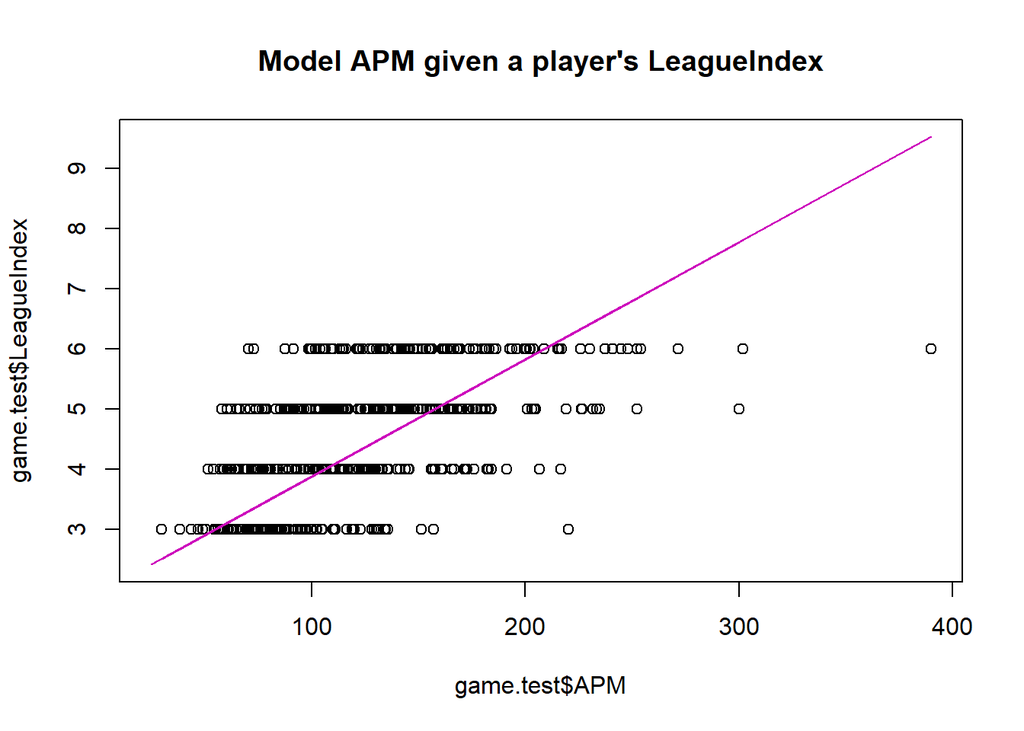

```r
pred.rq=predict(game.train.rq,game.test)

plot(game.test$APM,game.test$LeagueIndex,ylim=c(min(pred.rq),max(pred.rq)),main="Model APM given a player's LeagueIndex")

lines(game.test$APM,pred.rq,col=6)
```

### Q1 a.4) present scatter plot of test data for model with predictor log( APM )

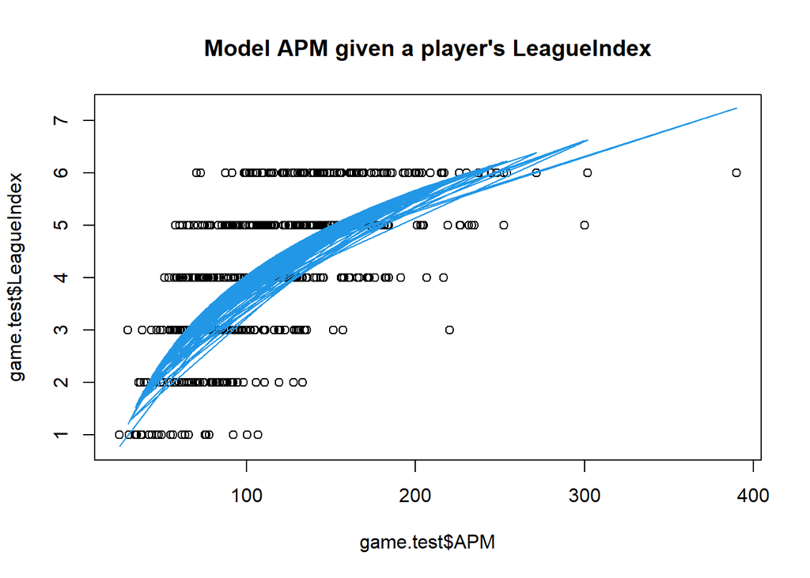

```r
pred.rqLo=predict(game.train.rqLo,game.test)
plot(game.test$APM,game.test$LeagueIndex,ylim=c(min(pred.rqLo),max(pred.rqLo)),main="Model APM given a player's LeagueIndex")
lines(game.test$APM,pred.rqLo,col=4)
```

### Q1 (b) For Q1 a), 2 quantile regsn, which is the better one?

### Justify your answer with quantitative evidence [4 marks]

### MY ANSWER:

### model LeagueIndex ~ log(APM) is better due to less MSE and less AIC.

```r
# MSE > MSE_Log, the less MSE, the better predictility

(MSE=mean  ( ( game.test$LeagueIndex - pred.rq)^2))
```

```
## [1] 1.219144
```

```r
(MSE_Log=mean((game.test$LeagueIndex - pred.rqLo)^2))
```

```
## [1] 1.08045
```

```r
# Alternatively
AIC(game.train.rq)
```

```
## [1] 10548.13
## attr(,"edf")
## [1] 2
```

```r
AIC(game.train.rqLo)
```

```
## [1] 10199.23
## attr(,"edf")
## [1] 2
```

### Q1 (c) Using your model choice in (b), t a 0.1 and 0.9 qunatile regressions.

### Present a scatter plot of observations in Craft test.csv and 0.1 and

### 0.9 quantile prediction in a single plot. [4 marks]

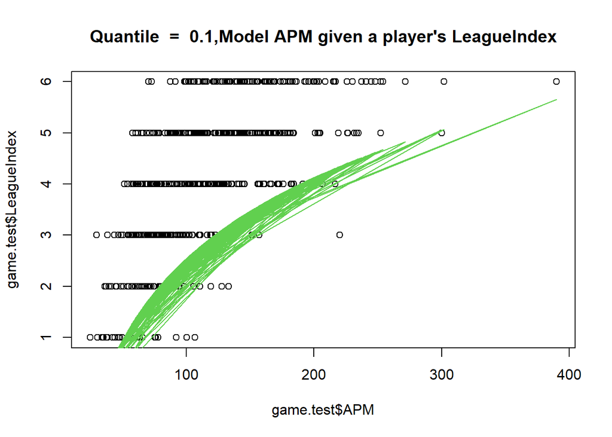

```r
game.train.rq1=rq(LeagueIndex ~ log(APM),    game.train,  tau=0.1)

pred.rq1=predict(game.train.rq1,   game.test)


plot(game.test$APM,  game.test$LeagueIndex,main="Quantile  =  0.1,Model APM given a player's LeagueIndex")
lines(game.test$APM,pred.rq1,col=3 )
```

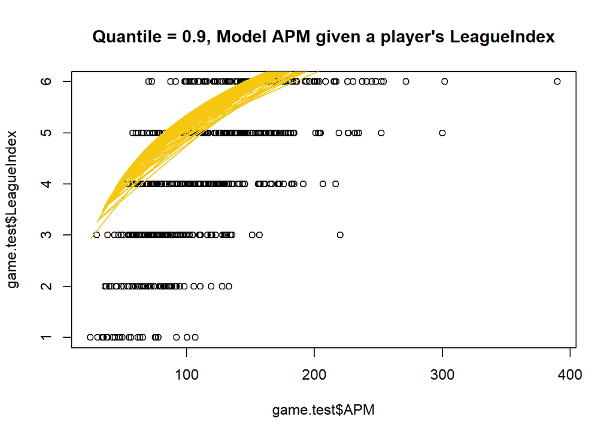

```r
game.train.rq9=rq(LeagueIndex ~ log(APM),  game.train,   tau=0.9)

pred.rq9=predict(game.train.rq9,   game.test)
plot(game.test$APM, game.test$LeagueIndex,  main="Quantile = 0.9, Model APM given a player's LeagueIndex")
lines(game.test$APM,     pred.rq9,   col=7)
```

### Q1 (d) for quantile 0.1,0.5,0.9 the [5 marks]

### We have three quantile regressions; 0.1 and 0.9 quantile regressions

### from (c) and your chocie of 0.5 quantile regression in (b). Is pre-

### dictability of quantile regression equally good for all league indices?

### Write the best quantile prediction for each league index. [5 marks]

### MY ANSWER:

### With a close look at the three diagram of the 3 models (quantile is 0.1,0.5,0.9),

### the conclusion below based on the amount of over-estimated predictions are relatively

### equal to the amout of under-estimated ### predictions.

### LeagueIndex 2,3 is better predicted by the model with Quantile = 0.1

### LeagueIndex 4,5 is better predicted by the model with Quantile = 0.5

### LeagueIndex 5,6 is better predicted by the model with Quantile = 0.9

### LeagueIndex 1 is worst predicted by three models.

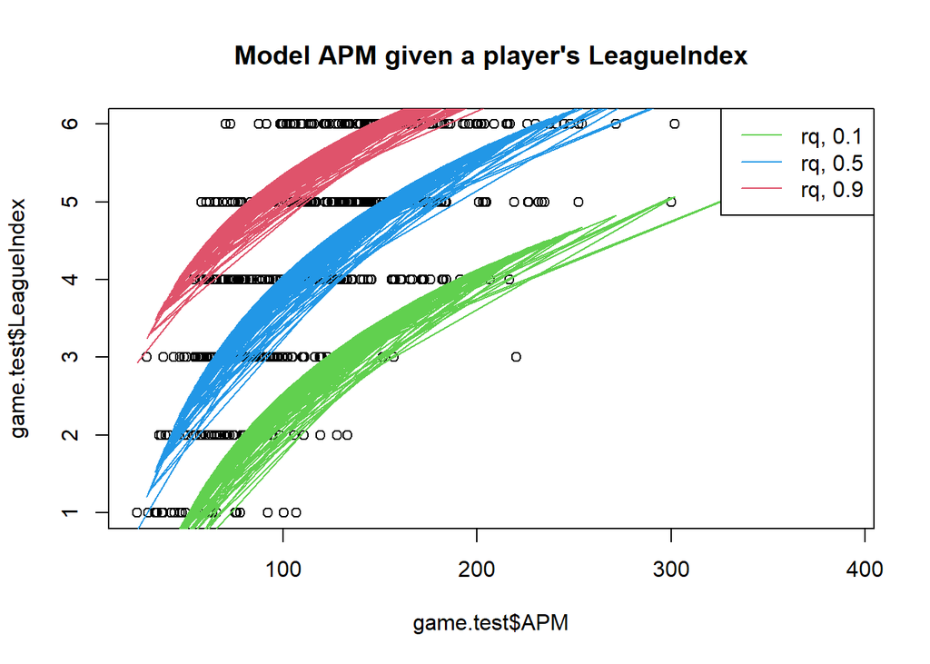

```r
T=c(0.1,  0.5,   0.9)
pred=matrix(,length(T),nrow(game.test))
for (t in 1:length(T)) {
  pred[t,]=predict(rq(LeagueIndex~log(APM), game.train, tau=T[t]),game.test)
}

plot(game.test$APM,game.test$LeagueIndex,main = "Model APM given a player's LeagueIndex" )
lines(game.test$APM,pred[1,],col=3)
lines(game.test$APM,pred[2,],col=4)
lines(game.test$APM,pred[3,],col=2)
legend("topright", legend = c(paste("rq,",as.character(T))), col = c(3,4,2),lty = 1)
```

### Q1 d) Quantitive evidence:

### leagueIndex of 2,3 is best predicted by q=0.1,since 2 or 3 category has higher predicted ratio against test data

```r
game.test$LeagueIndex=as.factor(game.test$LeagueIndex)

table(round(pred.rq1))[c("1","2","3","4","5","6")]/table(game.test$LeagueIndex)
```

```
##
##           1           2           3           4           5           6
## 1.896551724 2.981481481 2.183673469 0.811023622 0.068493151 0.009708738
```

### Q1,d) The predictibility

### leagueIndex of 4,5 is best predicted by q=0.5,since 4 or 5 category has higher predicted ratio against test data

```r
table(round(pred.rqLo))[c("1","2","3","4","5","6")]/table(game.test$LeagueIndex)
```

```
##
##         1         2         3         4         5         6
## 0.1034483 0.5740741 1.1428571 1.4488189 1.2671233 0.3786408
```

### Q1,d) The predictibility

### leagueIndex of 5,6 is best predicted by q=0.9,since 5 or 6 category has higher predicted ratio against test data

```r
table(round(pred.rq9))[c("1","2","3","4","5","6")]/table(game.test$LeagueIndex)
```

```
##
##       <NA>       <NA>          3          4          5          6
##                       0.04081633 0.44094488 1.48630137 2.34951456
```

### Question 2

### We want to model the league index (LeagueIndex) of a player given

### his/her screen movements. The covariates GameID, Age, HoursPerWeek

### and TotalHours are excluded in this analysis.

### The distribution of levels of expertise (LeagueIndex) in the train dataset

### LeagueIndex 1 2 3 4 5 6

### Probability 0:05 0:10 0:17 0:25 0:24 0:19

### Q2 (a) Fit the best and parsimonious linear regression models for LeagueIndex

### using the l1 norm penalty. Present a plot showing the number of non-

### zero coecients against . Make sure you x the randomization using

### set.seed(1234) before tting a regression. [4 marks]

```r
library(glmnet); #Ridge and Lasso
library(grpreg); #Group lasso
set.seed(1234)
game.train=read.csv(file='Craft_train.csv',header=TRUE)
game.test=read.csv(file='Craft_test.csv',header=TRUE)

game.train2=game.train[,!names(game.train)%in% c("GameID","Age","HoursPerWeek","TotalHours")]
game.test2=game.test[,!names(game.test)%in% c("GameID","Age","HoursPerWeek","TotalHours")]

game.train2$LeagueIndex=as.factor(game.train2$LeagueIndex)
game.test2$LeagueIndex=as.factor(game.test2$LeagueIndex)
```

### Q2 a.1) fit the best and parsimonious linear regression model for LeagueIndex using the l1 NORM penalty